# TP 1 - Correction

Traitement des données

INTECHMER - CT2 GEM/PVRM

## Importation

```r
library(tidyverse)
library(knitr)      # pour la fonction kable() surtout
library(kableExtra) # pour le style des tables affichées avec kable()

adult = read_csv("https://fxjollois.github.io/cours-2025-2026/intechmer-2a-stat-desc/adult.csv")
```

## Description de la population

### Âge

Les individus ont en moyenne **38,6 ans**, et se situent tous entre 17 et 90 ans.

```r
x = adult$age
tab = data.frame(
  Information = c("Moyenne", "Ecart-type", "Minimum", "Maximum"),
  Valeur = c(mean(x), sd(x), min(x), max(x))
)
kable(tab, digits = 2) %>%
  kable_styling(full_width = F)
```

| Information | Valeur |
| --- | --- |
| Moyenne | 38.58 |
| Ecart-type | 13.64 |
| Minimum | 17.00 |
| Maximum | 90.00 |

On remarque qu’un majorité des individus ont entre 25 et 50 ans.

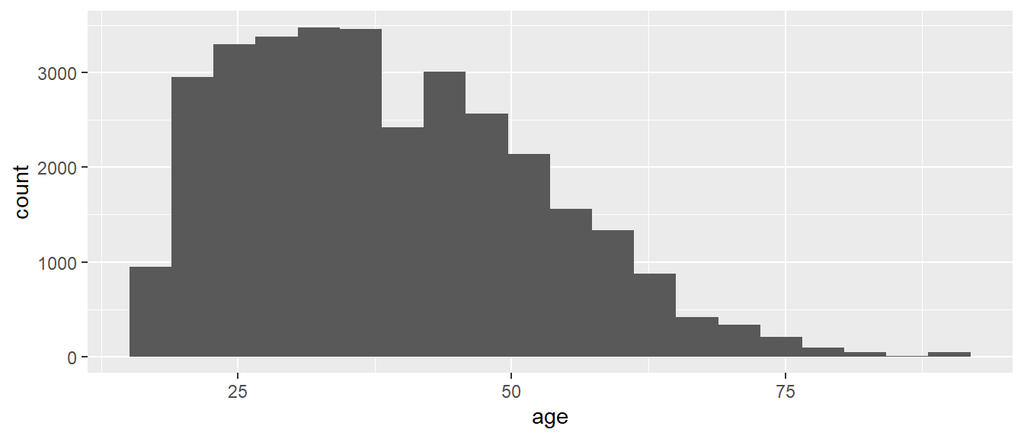

```r
ggplot(adult, aes(age)) +
  geom_histogram(bins = 20)
```

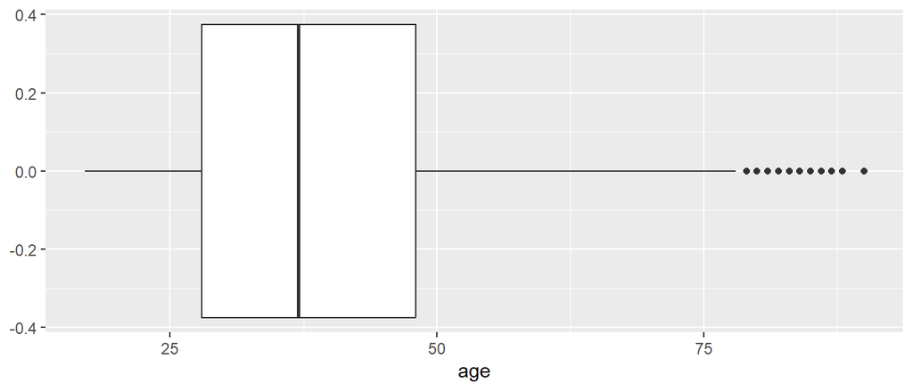

```r
ggplot(adult, aes(age)) +
  geom_boxplot()
```

### Nombre d’heures de travail

Les individus travaillent très majoritairement 40 heures par semaine, avec une étendue très large - de 1 heure par semaine à 99 heures par semaine.

```r
x = adult$hours_per_week
tab = data.frame(
  Information = c("Moyenne", "Ecart-type", "Minimum", "Maximum"),
  Valeur = c(mean(x), sd(x), min(x), max(x))
)
kable(tab, digits = 2) %>%
  kable_styling(full_width = F)
```

| Information | Valeur |
| --- | --- |
| Moyenne | 40.44 |
| Ecart-type | 12.35 |
| Minimum | 1.00 |
| Maximum | 99.00 |

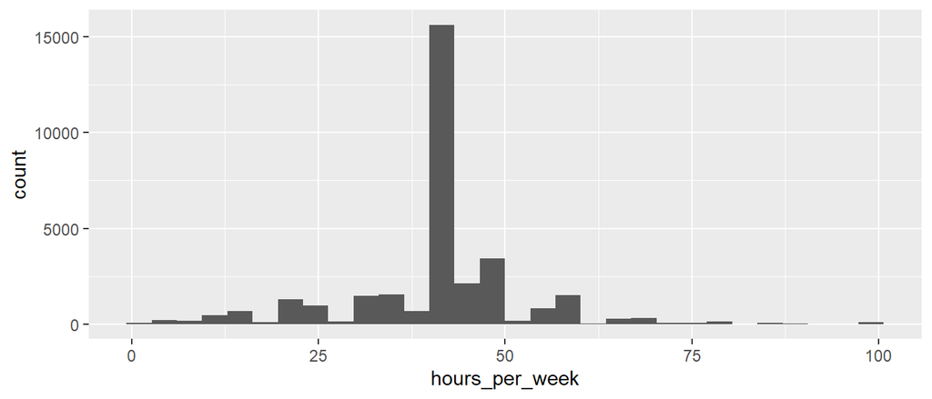

```r
ggplot(adult, aes(hours_per_week)) +
  geom_histogram()
```

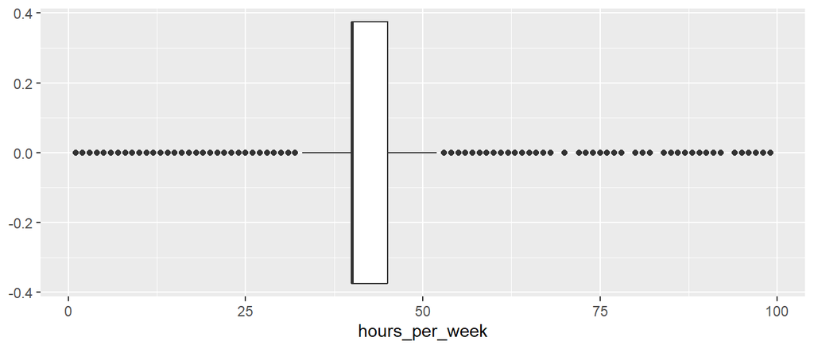

```r
ggplot(adult, aes(hours_per_week)) +
  geom_boxplot()
```

### Investissements

#### Gain

```r
x = adult$capital_gain
tab = data.frame(
  Information = c("Moyenne", "Ecart-type", "Minimum", "Maximum"),
  Valeur = c(mean(x), sd(x), min(x), max(x))
)
kable(tab, digits = 2) %>%
  kable_styling(full_width = F)
```

| Information | Valeur |
| --- | --- |
| Moyenne | 1077.65 |
| Ecart-type | 7385.29 |
| Minimum | 0.00 |
| Maximum | 99999.00 |

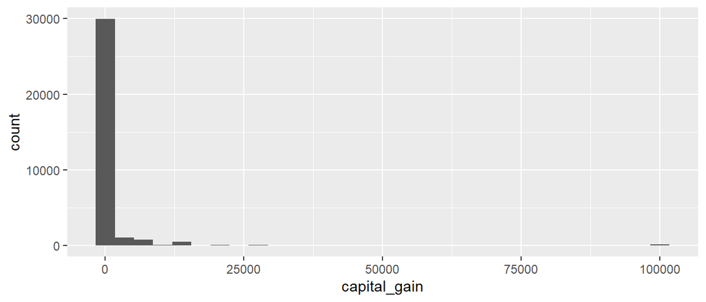

```r
ggplot(adult, aes(capital_gain)) +
  geom_histogram()
```

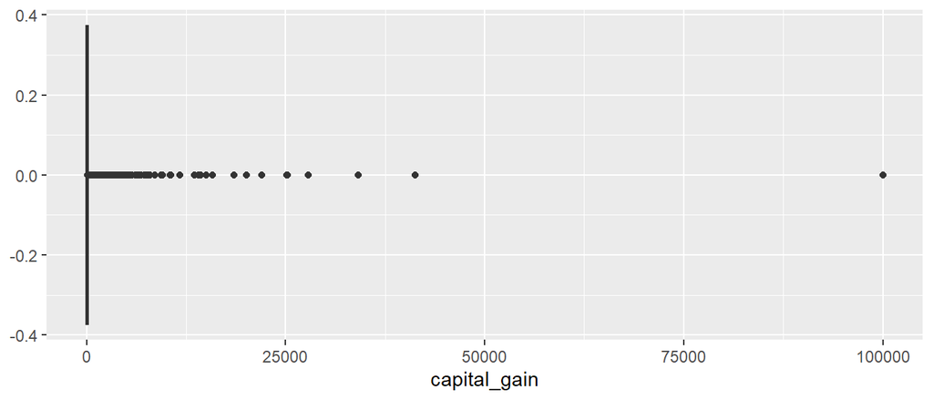

```r
ggplot(adult, aes(capital_gain)) +
  geom_boxplot()
```

#### Perte

```r
x = adult$capital_loss
tab = data.frame(
  Information = c("Moyenne", "Ecart-type", "Minimum", "Maximum"),
  Valeur = c(mean(x), sd(x), min(x), max(x))
)
kable(tab, digits = 2) %>%
  kable_styling(full_width = F)
```

| Information | Valeur |
| --- | --- |
| Moyenne | 87.30 |
| Ecart-type | 402.96 |
| Minimum | 0.00 |
| Maximum | 4356.00 |

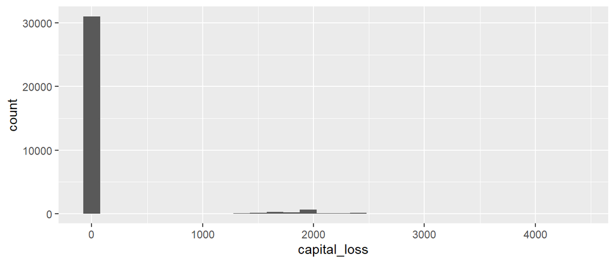

```r
ggplot(adult, aes(capital_loss)) +
  geom_histogram()
```

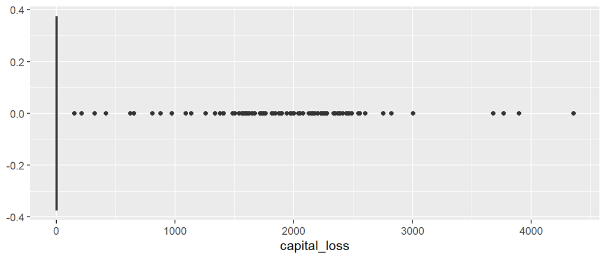

```r
ggplot(adult, aes(capital_loss)) +
  geom_boxplot()
```

#### Modification de ces deux variables

On peut envisager plusieurs modifications de ces deux variables :

- En créer une nouvelle égale aux gains moins les pertes
  - Cette variable sera positive s’il y a eu gain, négative s’il y a eu perte et égale à 0 si aucun investissement
- Les transformer en binaire (`TRUE`/`FALSE`) :
  - `TRUE` si le montant est supérieur à 0
- Ré-utiliser la première idée pour créer une variable ternaire à trois modalités : *Gain*, *Perte*, *Aucun*
- Créer deux variables imbriquées :
  - Une première égale à `TRUE` s’il y a investissement (*i.e.* il y a soit un gain, soit une perte) et `FALSE` sinon
  - Une deuxième égale à `TRUE` s’il y a *Gain* et `FALSE` si *Perte*, uniquement pour les individus ayant `TRUE` à la variable précédente

Voici le code pour créer ces nouvelles variables

```r
adult_newvars_capital = adult %>%

  # Création de la variable capital_res = gain - perte
  mutate(capital_res = capital_gain - capital_loss) %>%

  # Création des deux variables binaires
  mutate(capital_gain_bin = capital_gain > 0,
         capital_loss_bin = capital_loss > 0) %>%

  # Création de la variable ternaire
  mutate(capital_res_cat = ifelse(capital_res > 0,
                                  "Gain",
                                  ifelse(capital_res < 0,
                                         "Perte",
                                         "Aucun"))) %>%

  # Création des deux variables imbriquées
  mutate(capital_invest = capital_res != 0) %>%
  mutate(capital_invest_res = ifelse(capital_invest, capital_res > 0, NA))

# Affichage de ces nouvelles
kable(head(adult_newvars_capital, 10) %>%
        select(starts_with("capital")), digits = 2) %>%
  kable_styling(full_width = F)
```

| capital_gain | capital_loss | capital_res | capital_gain_bin | capital_loss_bin | capital_res_cat | capital_invest | capital_invest_res |
| --- | --- | --- | --- | --- | --- | --- | --- |
| 2174 | 0 | 2174 | TRUE | FALSE | Gain | TRUE | TRUE |
| 0 | 0 | 0 | FALSE | FALSE | Aucun | FALSE | NA |
| 0 | 0 | 0 | FALSE | FALSE | Aucun | FALSE | NA |
| 0 | 0 | 0 | FALSE | FALSE | Aucun | FALSE | NA |
| 0 | 0 | 0 | FALSE | FALSE | Aucun | FALSE | NA |
| 0 | 0 | 0 | FALSE | FALSE | Aucun | FALSE | NA |
| 0 | 0 | 0 | FALSE | FALSE | Aucun | FALSE | NA |
| 0 | 0 | 0 | FALSE | FALSE | Aucun | FALSE | NA |
| 14084 | 0 | 14084 | TRUE | FALSE | Gain | TRUE | TRUE |
| 5178 | 0 | 5178 | TRUE | FALSE | Gain | TRUE | TRUE |

Voici quelques graphiques pour voir ce qu’on obtient

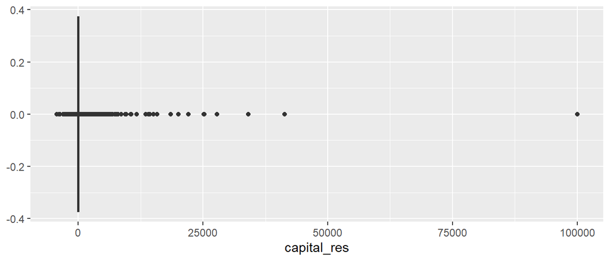

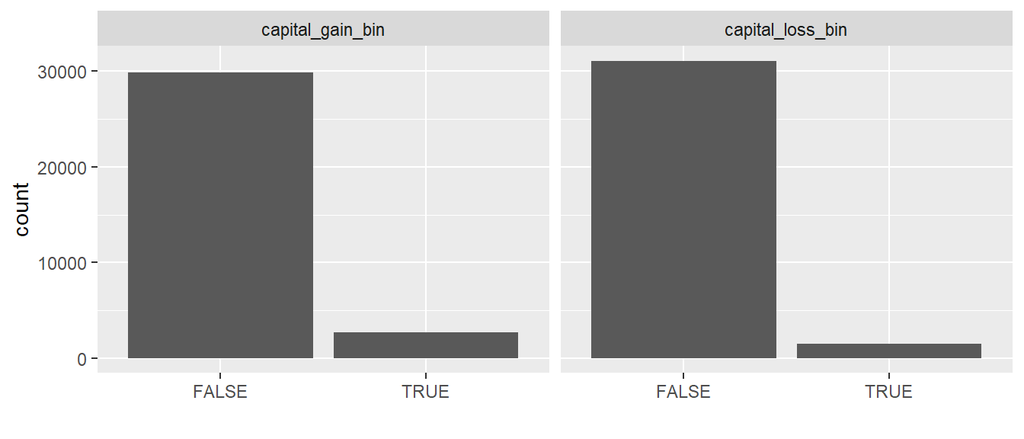

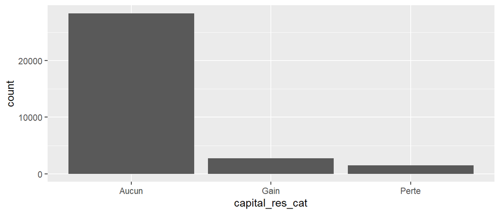

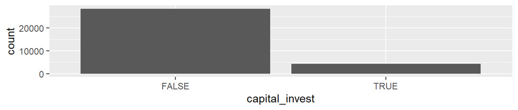

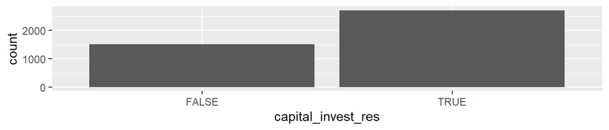

### Les 4 variables quantitatives en une fois

On peut produire un seul tableau avec les informations des 4 variables quantitatives, comme ci-dessous.

```r
x1 = adult$age
x2 = adult$hours_per_week
x3 = adult$capital_gain
x4 = adult$capital_loss
tab = data.frame(
  Information = c("Moyenne", "Ecart-type", "Minimum", "Maximum"),
  Age = c(mean(x1), sd(x1), min(x1), max(x1)),
  Travail = c(mean(x2), sd(x2), min(x2), max(x2)),
  Gain = c(mean(x3), sd(x3), min(x3), max(x3)),
  Perte = c(mean(x4), sd(x4), min(x4), max(x4))
)
kable(tab, digits = 2) %>%
  kable_styling(full_width = F)
```

| Information | Age | Travail | Gain | Perte |
| --- | --- | --- | --- | --- |
| Moyenne | 38.58 | 40.44 | 1077.65 | 87.30 |
| Ecart-type | 13.64 | 12.35 | 7385.29 | 402.96 |
| Minimum | 17.00 | 1.00 | 0.00 | 0.00 |
| Maximum | 90.00 | 99.00 | 99999.00 | 4356.00 |

Le même calcul de façon un peu plus automatique

```r
adult_quanti = adult %>%
  select(age, hours_per_week, capital_gain, capital_loss)
tab = data.frame(
  Moyenne = apply(adult_quanti, 2, mean),
  `Ecart-type` = apply(adult_quanti, 2, sd),
  Minimum = apply(adult_quanti, 2, min),
  Maximum = apply(adult_quanti, 2, max)) %>%
  t() %>%
  data.frame()
names(tab) = c("Age", "Travail", "Gain", "Perte")
kable(tab, digits = 2) %>%
  kable_styling(full_width = F)
```

|  | Age | Travail | Gain | Perte |
| --- | --- | --- | --- | --- |
| Moyenne | 38.58 | 40.44 | 1077.65 | 87.30 |
| Ecart.type | 13.64 | 12.35 | 7385.29 | 402.96 |
| Minimum | 17.00 | 1.00 | 0.00 | 0.00 |
| Maximum | 90.00 | 99.00 | 99999.00 | 4356.00 |

En version un peu compliquée tout de même

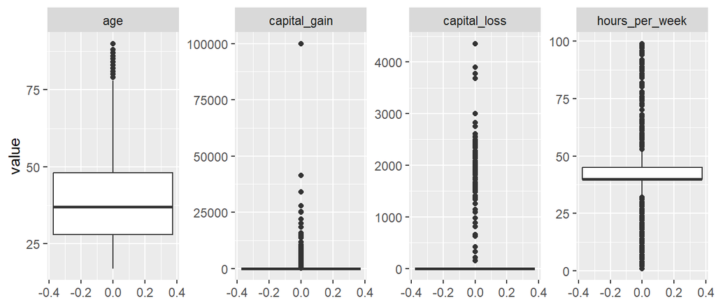

```r
adult %>%
  select(age, hours_per_week, capital_gain, capital_loss) %>%
  rownames_to_column("id") %>%
  pivot_longer(-id) %>%
  ggplot(aes(y = value)) +
  geom_boxplot() +
  facet_wrap(~ name, ncol = 4, scale = "free_y")
```

En version plus simple à comprendre, en utilisant le package [`gridExtra`](https://cran.r-project.org/web/packages/gridExtra/index.html).

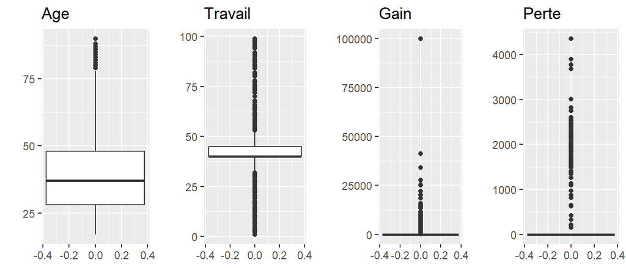

```r
library(gridExtra)

g1 = ggplot(adult, aes(y = age)) +
  geom_boxplot() + ggtitle("Age") + labs(y = "")
g2 = ggplot(adult, aes(y = hours_per_week)) +
  geom_boxplot() + ggtitle("Travail") + labs(y = "")
g3 = ggplot(adult, aes(y = capital_gain)) +
  geom_boxplot() + ggtitle("Gain") + labs(y = "")
g4 = ggplot(adult, aes(y = capital_loss)) +
  geom_boxplot() + ggtitle("Perte") + labs(y = "")
grid.arrange(g1, g2, g3, g4, ncol = 4)
```

### Salaire

Un quart des gens environ gagnent plus de 50 k$.

```r
tab = adult %>%
  group_by(class) %>%
  summarise(Nombre = n()) %>%
  mutate(Pourcent = round(Nombre / sum(Nombre) * 100, 2))
kable(tab) %>%
  kable_styling(full_width = F)
```

| class | Nombre | Pourcent |
| --- | --- | --- |
| <=50K | 24720 | 75.92 |
| >50K | 7841 | 24.08 |

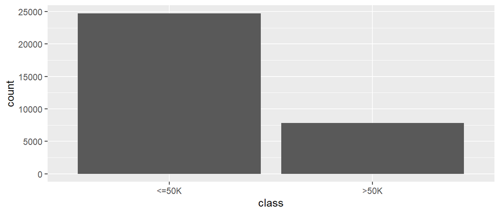

```r
ggplot(adult, aes(class)) +
  geom_bar()
```

### Sexe

On a une répartition inégale des sexes, avec un tiers de femmes seulement.

```r
tab = adult %>%
  group_by(sex) %>%
  summarise(Nombre = n()) %>%
  mutate(Pourcent = round(Nombre / sum(Nombre) * 100, 2))
kable(tab) %>%
  kable_styling(full_width = F)
```

| sex | Nombre | Pourcent |
| --- | --- | --- |
| Female | 10771 | 33.08 |
| Male | 21790 | 66.92 |

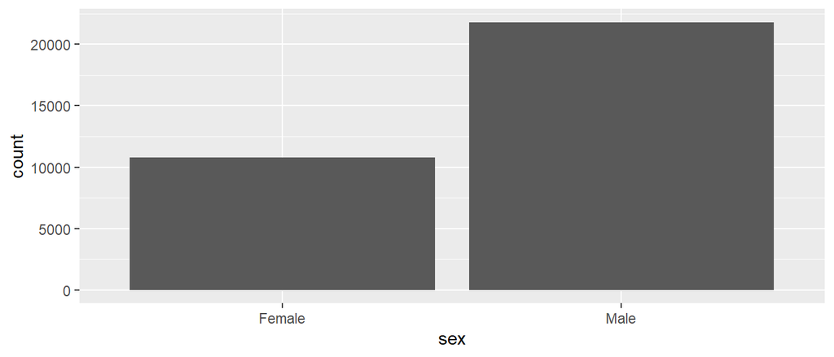

```r
ggplot(adult, aes(sex)) +
  geom_bar()
```

### Catégorie éthnique

Il y a bien évidemment une grande majorité de personnes dites *White* (85%), suivi par environ 10% de personnes dites *Black*. Les autres catégories sont très peu présentes (moins de 5% donc).

```r
tab = adult %>%
  group_by(race) %>%
  summarise(Nombre = n()) %>%
  mutate(Pourcent = round(Nombre / sum(Nombre) * 100, 2)) %>%
  arrange(desc(Nombre))
kable(tab) %>%
  kable_styling(full_width = F)
```

| race | Nombre | Pourcent |
| --- | --- | --- |
| White | 27816 | 85.43 |
| Black | 3124 | 9.59 |
| Asian-Pac-Islander | 1039 | 3.19 |
| Amer-Indian-Eskimo | 311 | 0.96 |
| Other | 271 | 0.83 |

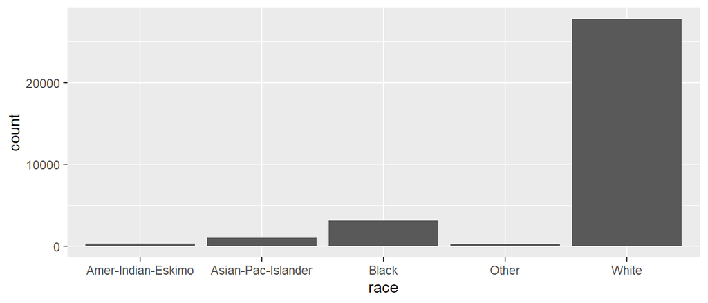

```r
ggplot(adult, aes(race)) +
  geom_bar()
```

### Statut marital

Presque la moitié de personnes sont mariées (environ 47% en prenant en considération les trois modalités concernées). Il y a par contre un tiers environ de personnes jamais mariés, et environ 20% de personnes divorcés (14%), séparés ou veuves (3% chaque modalité).

```r
tab = adult %>%
  group_by(marital_status) %>%
  summarise(Nombre = n()) %>%
  mutate(Pourcent = round(Nombre / sum(Nombre) * 100, 2)) %>%
  arrange(desc(Nombre))
kable(tab) %>%
  kable_styling(full_width = F)
```

| marital_status | Nombre | Pourcent |
| --- | --- | --- |
| Married-civ-spouse | 14976 | 45.99 |
| Never-married | 10683 | 32.81 |
| Divorced | 4443 | 13.65 |
| Separated | 1025 | 3.15 |
| Widowed | 993 | 3.05 |
| Married-spouse-absent | 418 | 1.28 |
| Married-AF-spouse | 23 | 0.07 |

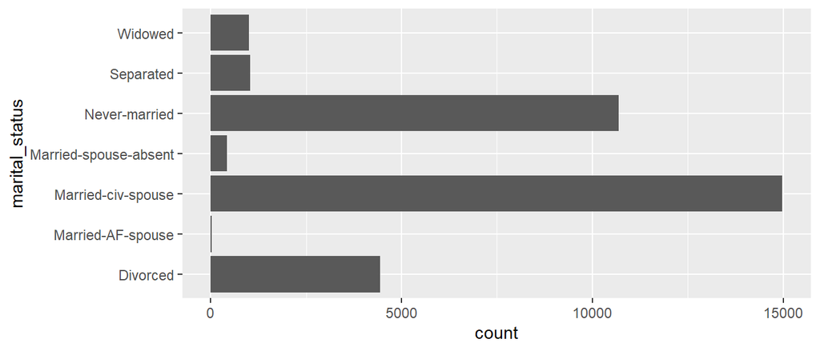

```r
ggplot(adult, aes(y = marital_status)) +
  geom_bar()
```

### Niveau d’éducation

Un peu plus de la moitié des personnes interrogées ont un niveau supérieur au Baccalauréat. Un tiers ont un niveau Baccalauréat (*HS-grad*), et donc environ 1 personne sur 6 a un niveau inférieur au Bac.

```r
tab = adult %>%
  group_by(education, education_num) %>%
  summarise(Nombre = n()) %>%
  ungroup() %>% # nécessaire car group_by() avec 2 variables
  mutate(Pourcent = round(Nombre / sum(Nombre) * 100, 2)) %>%
  arrange(desc(education_num))
kable(tab) %>%
  kable_styling(full_width = F)
```

| education | education_num | Nombre | Pourcent |
| --- | --- | --- | --- |
| Doctorate | 16 | 413 | 1.27 |
| Prof-school | 15 | 576 | 1.77 |
| Masters | 14 | 1723 | 5.29 |
| Bachelors | 13 | 5355 | 16.45 |
| Assoc-acdm | 12 | 1067 | 3.28 |
| Assoc-voc | 11 | 1382 | 4.24 |
| Some-college | 10 | 7291 | 22.39 |
| HS-grad | 9 | 10501 | 32.25 |
| 12th | 8 | 433 | 1.33 |
| 11th | 7 | 1175 | 3.61 |
| 10th | 6 | 933 | 2.87 |
| 9th | 5 | 514 | 1.58 |
| 7th-8th | 4 | 646 | 1.98 |
| 5th-6th | 3 | 333 | 1.02 |
| 1st-4th | 2 | 168 | 0.52 |
| Preschool | 1 | 51 | 0.16 |

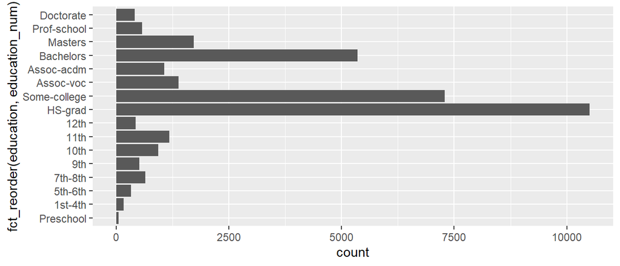

```r
ggplot(adult, aes(y = fct_reorder(education, education_num))) +
  geom_bar()
```

## Quels critères sont liés au salaire ?

- Décrire les liens entre chaque variable et le salaire ;

### Age, Travail, Gain et Perte

Les personnes gagnant plus de 50 k$ ont les caractéristiques suivantes :

- Elles sont plus âgées (44 ans vs 37 ans) ;
- Elles travaillent plus longtemps (45 heures vs 39 heures) ;
- Elles ont aussi des gains et des pertes plus élevés.

```r
tab = adult %>%
  select(class, age, hours_per_week, capital_gain, capital_loss) %>%
  group_by(class) %>%
  summarise_all(mean)
kable(tab, digits = 2) %>%
  kable_styling(full_width = F)
```

| class | age | hours_per_week | capital_gain | capital_loss |
| --- | --- | --- | --- | --- |
| <=50K | 36.78 | 38.84 | 148.75 | 53.14 |
| >50K | 44.25 | 45.47 | 4006.14 | 195.00 |

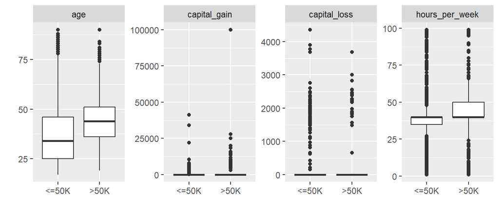

```r
adult %>%
  select(class, age, hours_per_week, capital_gain, capital_loss) %>%
  pivot_longer(-class) %>%
  ggplot(aes(x = class, y = value)) +
  geom_boxplot() +
  facet_wrap(~ name, ncol = 4, scale = "free_y") +
  labs(x = "", y = "")
```

### Sexe

Les femmes sont moins nombreuses à gagner plus de 50 k$.

```r
tab = adult %>%
  group_by(class, sex) %>%
  summarise(nb = n()) %>%
  pivot_wider(names_from = sex, values_from = nb)
kable(tab) %>%
  kable_styling(full_width = F)
```

| class | Female | Male |
| --- | --- | --- |
| <=50K | 9592 | 15128 |
| >50K | 1179 | 6662 |

```r
tab = prop.table(table(adult$class, adult$sex), margin = 2) * 100
kable(tab, digits = 2) %>%
  kable_styling(full_width = F)
```

|  | Female | Male |
| --- | --- | --- |
| <=50K | 89.05 | 69.43 |
| >50K | 10.95 | 30.57 |

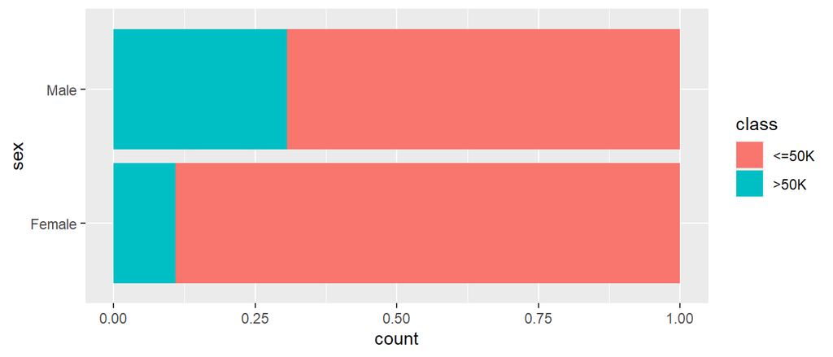

```r
ggplot(adult, aes(y = sex, fill = class)) +
  geom_bar(position = "fill")
```

### Type de travail

Plus d’une personne sur deux étant *Self-emp-inc* gagnent plus de 50 k$. Sans surprise, les personnes *Without-pay* ou *Never-worked* ne gagnent jamais plus de 50 k$.

```r
tab = adult %>%
  group_by(class, workclass) %>%
  summarise(nb = n()) %>%
  pivot_wider(names_from = workclass, values_from = nb)
kable(tab) %>%
  kable_styling(full_width = F)
```

| class | ? | Federal-gov | Local-gov | Never-worked | Private | Self-emp-inc | Self-emp-not-inc | State-gov | Without-pay |
| --- | --- | --- | --- | --- | --- | --- | --- | --- | --- |
| <=50K | 1645 | 589 | 1476 | 7 | 17733 | 494 | 1817 | 945 | 14 |
| >50K | 191 | 371 | 617 | NA | 4963 | 622 | 724 | 353 | NA |

```r
tab = prop.table(table(adult$class, adult$workclass), margin = 2) * 100
kable(tab, digits = 2) %>%
  kable_styling(full_width = F)
```

|  | ? | Federal-gov | Local-gov | Never-worked | Private | Self-emp-inc | Self-emp-not-inc | State-gov | Without-pay |
| --- | --- | --- | --- | --- | --- | --- | --- | --- | --- |
| <=50K | 89.6 | 61.35 | 70.52 | 100 | 78.13 | 44.27 | 71.51 | 72.8 | 100 |
| >50K | 10.4 | 38.65 | 29.48 | 0 | 21.87 | 55.73 | 28.49 | 27.2 | 0 |

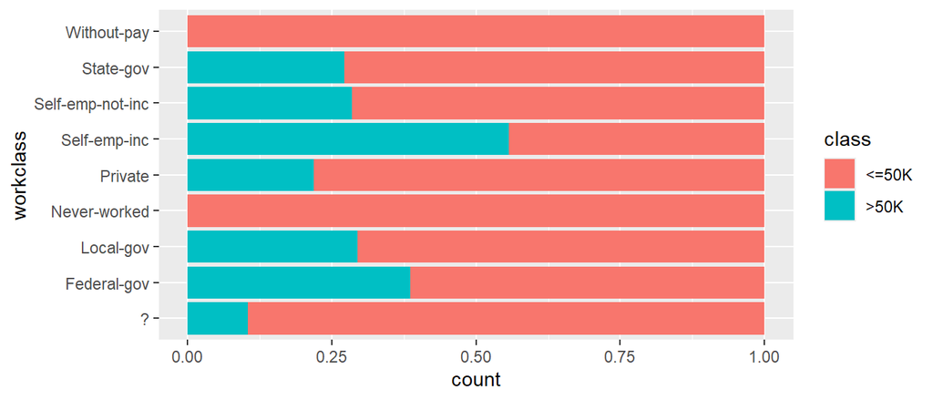

```r
ggplot(adult, aes(y = workclass, fill = class)) +
  geom_bar(position = "fill")
```

### Education

On voit très clairement que plus les études sont longues, plus la part de personnes gagnant plus de 50 k$ est importante.

```r
tab = adult %>%
  group_by(class, education_num, education) %>%
  summarise(nb = n()) %>%
  arrange(desc(education_num)) %>%
  ungroup() %>%
  select(-education_num) %>%
  pivot_wider(names_from = education, values_from = nb)
kable(tab) %>%
  kable_styling(full_width = F)
```

| class | Doctorate | Prof-school | Masters | Bachelors | Assoc-acdm | Assoc-voc | Some-college | HS-grad | 12th | 11th | 10th | 9th | 7th-8th | 5th-6th | 1st-4th | Preschool |
| --- | --- | --- | --- | --- | --- | --- | --- | --- | --- | --- | --- | --- | --- | --- | --- | --- |
| <=50K | 107 | 153 | 764 | 3134 | 802 | 1021 | 5904 | 8826 | 400 | 1115 | 871 | 487 | 606 | 317 | 162 | 51 |
| >50K | 306 | 423 | 959 | 2221 | 265 | 361 | 1387 | 1675 | 33 | 60 | 62 | 27 | 40 | 16 | 6 | NA |

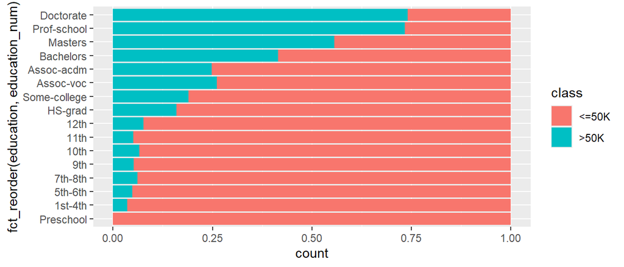

```r
ggplot(adult, aes(y = fct_reorder(education, education_num),
                  fill = class)) +
  geom_bar(position = "fill")
```

### Statut marital

Les personnes mariées gagnent plus souvent plus de 50 k$ que les autres.

```r
tab = adult %>%
  group_by(class, marital_status) %>%
  summarise(nb = n()) %>%
  pivot_wider(names_from = marital_status, values_from = nb)
kable(tab) %>%
  kable_styling(full_width = F)
```

| class | Divorced | Married-AF-spouse | Married-civ-spouse | Married-spouse-absent | Never-married | Separated | Widowed |
| --- | --- | --- | --- | --- | --- | --- | --- |
| <=50K | 3980 | 13 | 8284 | 384 | 10192 | 959 | 908 |
| >50K | 463 | 10 | 6692 | 34 | 491 | 66 | 85 |

```r
tab = prop.table(table(adult$class, adult$marital_status), margin = 2) * 100
kable(tab, digits = 2) %>%
  kable_styling(full_width = F)
```

|  | Divorced | Married-AF-spouse | Married-civ-spouse | Married-spouse-absent | Never-married | Separated | Widowed |
| --- | --- | --- | --- | --- | --- | --- | --- |
| <=50K | 89.58 | 56.52 | 55.32 | 91.87 | 95.4 | 93.56 | 91.44 |
| >50K | 10.42 | 43.48 | 44.68 | 8.13 | 4.6 | 6.44 | 8.56 |

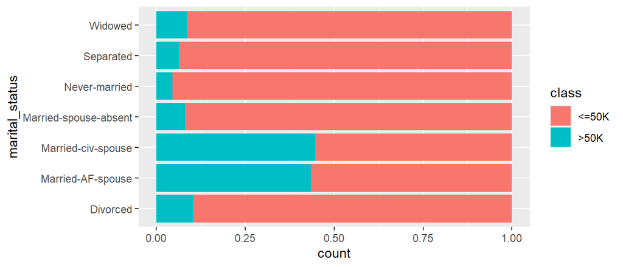

```r
ggplot(adult, aes(y = marital_status, fill = class)) +
  geom_bar(position = "fill")
```

### Occupation

On remarque que certaines catégories sociales permettent plus facilement l’accès à un salaire élevé.

```r
tab = adult %>%
  group_by(class, occupation) %>%
  summarise(nb = n()) %>%
  pivot_wider(names_from = occupation, values_from = nb)
kable(tab) %>%
  kable_styling(full_width = F)
```

| class | ? | Adm-clerical | Armed-Forces | Craft-repair | Exec-managerial | Farming-fishing | Handlers-cleaners | Machine-op-inspct | Other-service | Priv-house-serv | Prof-specialty | Protective-serv | Sales | Tech-support | Transport-moving |
| --- | --- | --- | --- | --- | --- | --- | --- | --- | --- | --- | --- | --- | --- | --- | --- |
| <=50K | 1652 | 3263 | 8 | 3170 | 2098 | 879 | 1284 | 1752 | 3158 | 148 | 2281 | 438 | 2667 | 645 | 1277 |
| >50K | 191 | 507 | 1 | 929 | 1968 | 115 | 86 | 250 | 137 | 1 | 1859 | 211 | 983 | 283 | 320 |

```r
tab = prop.table(table(adult$class, adult$occupation), margin = 2) * 100
kable(tab, digits = 2) %>%
  kable_styling(full_width = F)
```

|  | ? | Adm-clerical | Armed-Forces | Craft-repair | Exec-managerial | Farming-fishing | Handlers-cleaners | Machine-op-inspct | Other-service | Priv-house-serv | Prof-specialty | Protective-serv | Sales | Tech-support | Transport-moving |
| --- | --- | --- | --- | --- | --- | --- | --- | --- | --- | --- | --- | --- | --- | --- | --- |
| <=50K | 89.64 | 86.55 | 88.89 | 77.34 | 51.6 | 88.43 | 93.72 | 87.51 | 95.84 | 99.33 | 55.1 | 67.49 | 73.07 | 69.5 | 79.96 |
| >50K | 10.36 | 13.45 | 11.11 | 22.66 | 48.4 | 11.57 | 6.28 | 12.49 | 4.16 | 0.67 | 44.9 | 32.51 | 26.93 | 30.5 | 20.04 |

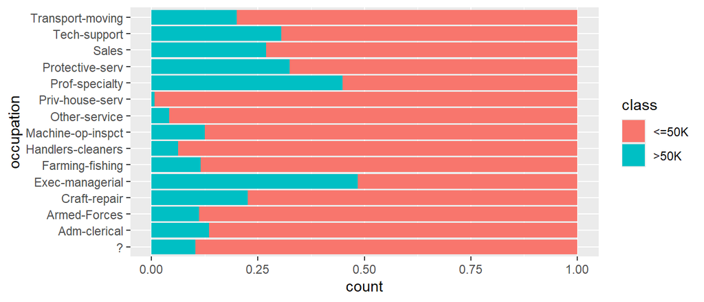

```r
ggplot(adult, aes(y = occupation, fill = class)) +
  geom_bar(position = "fill")
```

### Race

Ici aussi, on remarque une différence entre les différentes catégories ethniques pour l’accès à des salaires supérieurs à 50 k$.

```r
tab = adult %>%
  group_by(class, race) %>%
  summarise(nb = n()) %>%
  pivot_wider(names_from = race, values_from = nb)
kable(tab) %>%
  kable_styling(full_width = F)
```

| class | Amer-Indian-Eskimo | Asian-Pac-Islander | Black | Other | White |
| --- | --- | --- | --- | --- | --- |
| <=50K | 275 | 763 | 2737 | 246 | 20699 |
| >50K | 36 | 276 | 387 | 25 | 7117 |

```r
tab = prop.table(table(adult$class, adult$race), margin = 2) * 100
kable(tab, digits = 2) %>%
  kable_styling(full_width = F)
```

|  | Amer-Indian-Eskimo | Asian-Pac-Islander | Black | Other | White |
| --- | --- | --- | --- | --- | --- |
| <=50K | 88.42 | 73.44 | 87.61 | 90.77 | 74.41 |
| >50K | 11.58 | 26.56 | 12.39 | 9.23 | 25.59 |

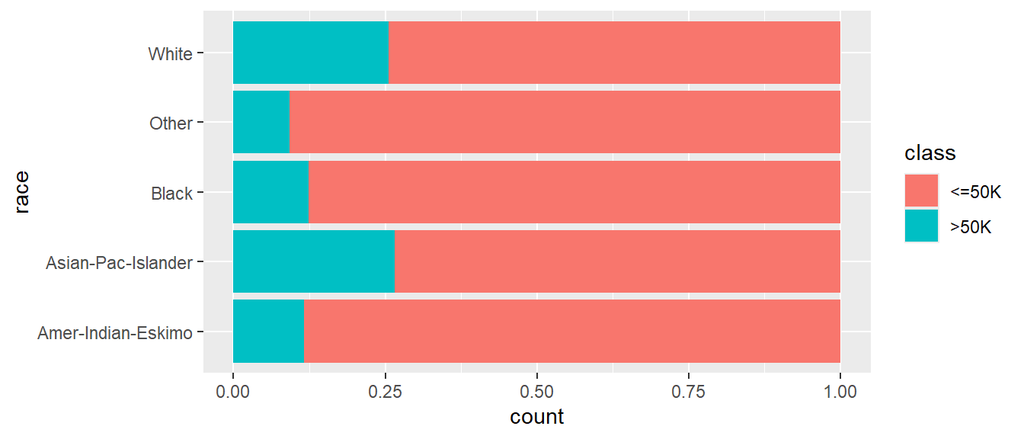

```r
ggplot(adult, aes(y = race, fill = class)) +
  geom_bar(position = "fill")
```

### Pays de naissance

La part de personnes gagnant plus de 50 k$ changent parfois énormément selon le pays d’origine. Près de 40% des personnes venant de France, par exemple, ont un salaire élevé.

```r
tab = adult %>%
  group_by(class, native_country) %>%
  summarise(nb = n()) %>%
  pivot_wider(names_from = native_country, values_from = nb)
kable(tab) %>%
  kable_styling(full_width = F)
```

| class | ? | Cambodia | Canada | China | Columbia | Cuba | Dominican-Republic | Ecuador | El-Salvador | England | France | Germany | Greece | Guatemala | Haiti | Holand-Netherlands | Honduras | Hong | Hungary | India | Iran | Ireland | Italy | Jamaica | Japan | Laos | Mexico | Nicaragua | Outlying-US(Guam-USVI-etc) | … |
| --- | --- | --- | --- | --- | --- | --- | --- | --- | --- | --- | --- | --- | --- | --- | --- | --- | --- | --- | --- | --- | --- | --- | --- | --- | --- | --- | --- | --- | --- | --- |
| <=50K | 437 | 12 | 82 | 55 | 57 | 70 | 68 | 24 | 97 | 60 | 17 | 93 | 21 | 61 | 40 | 1 | 12 | 14 | 10 | 60 | 25 | 19 | 48 | 71 | 38 | 16 | 610 | 32 | 14 | … |
| >50K | 146 | 7 | 39 | 20 | 2 | 25 | 2 | 4 | 9 | 30 | 12 | 44 | 8 | 3 | 4 | NA | 1 | 6 | 3 | 40 | 18 | 5 | 25 | 10 | 24 | 2 | 33 | 2 | NA | … |

```r
tab = prop.table(table(adult$class, adult$native_country), margin = 2) * 100
kable(tab, digits = 2) %>%
  kable_styling(full_width = F)
```

|  | ? | Cambodia | Canada | China | Columbia | Cuba | Dominican-Republic | Ecuador | El-Salvador | England | France | Germany | Greece | Guatemala | Haiti | Holand-Netherlands | Honduras | Hong | Hungary | India | Iran | Ireland | Italy | Jamaica | Japan | Laos | Mexico | Nicaragua | Outlying-US(Guam-USVI-etc) | … |
| --- | --- | --- | --- | --- | --- | --- | --- | --- | --- | --- | --- | --- | --- | --- | --- | --- | --- | --- | --- | --- | --- | --- | --- | --- | --- | --- | --- | --- | --- | --- |
| <=50K | 74.96 | 63.16 | 67.77 | 73.33 | 96.61 | 73.68 | 97.14 | 85.71 | 91.51 | 66.67 | 58.62 | 67.88 | 72.41 | 95.31 | 90.91 | 100 | 92.31 | 70 | 76.92 | 60 | 58.14 | 79.17 | 65.75 | 87.65 | 61.29 | 88.89 | 94.87 | 94.12 | 100 | … |
| >50K | 25.04 | 36.84 | 32.23 | 26.67 | 3.39 | 26.32 | 2.86 | 14.29 | 8.49 | 33.33 | 41.38 | 32.12 | 27.59 | 4.69 | 9.09 | 0 | 7.69 | 30 | 23.08 | 40 | 41.86 | 20.83 | 34.25 | 12.35 | 38.71 | 11.11 | 5.13 | 5.88 | 0 | … |

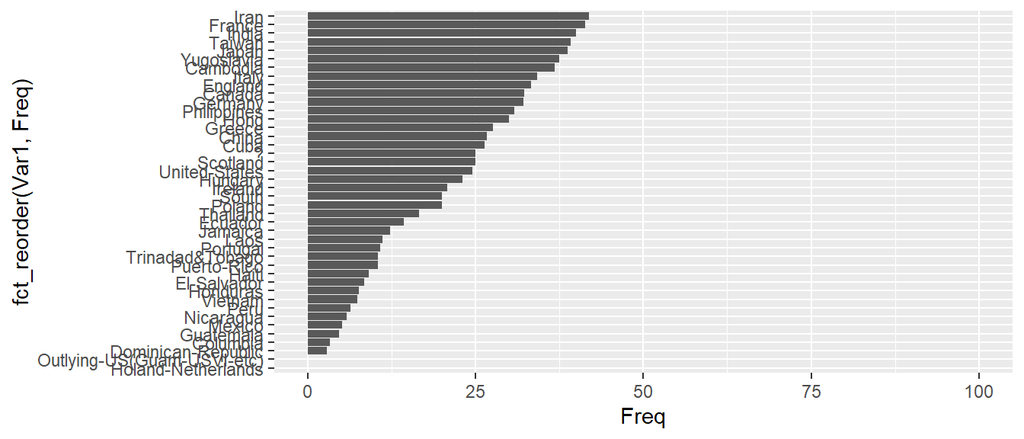

```r
tab2 = t(tab) %>%
  data.frame() %>%
  filter(Var2 == ">50K")
ggplot(tab2,
       aes(y = fct_reorder(Var1, Freq), x = Freq)) +
  geom_bar(stat = "identity") +
  xlim(0, 100)
```

## Quelques liens entre variables

### Âge et nombre d’heures de travail

Pas de tendance visible directement (certainement dû au caractère particulier de la variable nombre d’heures de travail – beaucoup de personnes à 40h exactement)

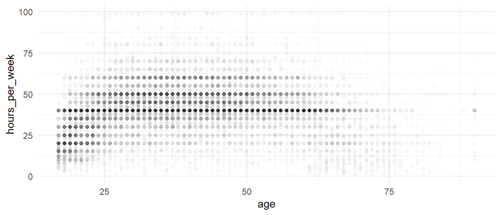

```r
ggplot(adult, aes(age, hours_per_week)) +
  geom_point(alpha = .01) +
  theme_minimal()
```

En modifiant la variable nombre d’heures par semaine, on remarque que les gens travaillant 40h ou plus sont plus agées que ceux travaillant moins.

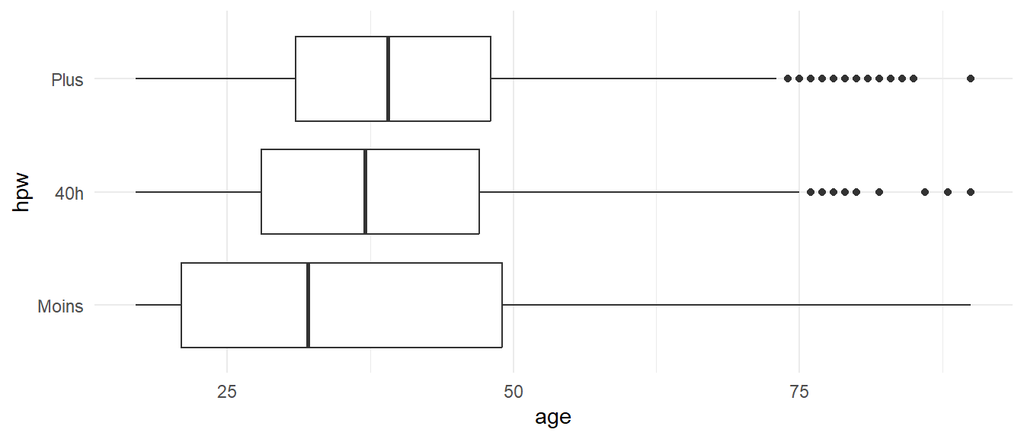

```r
adult %>%
  mutate(hpw = ifelse(hours_per_week > 40,
                      "Plus",
                      ifelse(hours_per_week < 40,
                             "Moins",
                             "40h"))) %>%
  ggplot(aes(age, hpw)) +
  geom_boxplot() +
  scale_y_discrete(limits = c("Moins", "40h", "Plus")) +
  theme_minimal()
```

On peut aussi modifier la variable age. On remarque que les gens entre 25 et 55 travaillent plus que les autres.

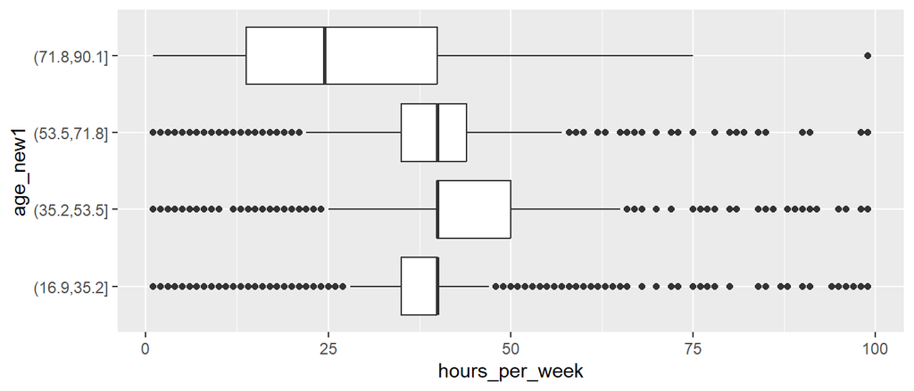

```r
adult2 = adult %>%
  mutate(age_new1 = cut(age, 4),
         age_new2 = cut(age, c(0, 25, 40, 60, 100)))
ggplot(adult2, aes(hours_per_week, age_new1)) +
  geom_boxplot()
```

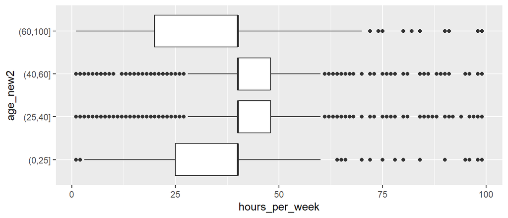

```r
ggplot(adult2, aes(hours_per_week, age_new2)) +
  geom_boxplot()
```

### Âge et investissement (les deux variables `capital_xxx`).

Idem que précédemment, difficile de faire une conclusion sur la base de ce graphique, encore une fois à cause du caractère particulier des variables sur le capital.

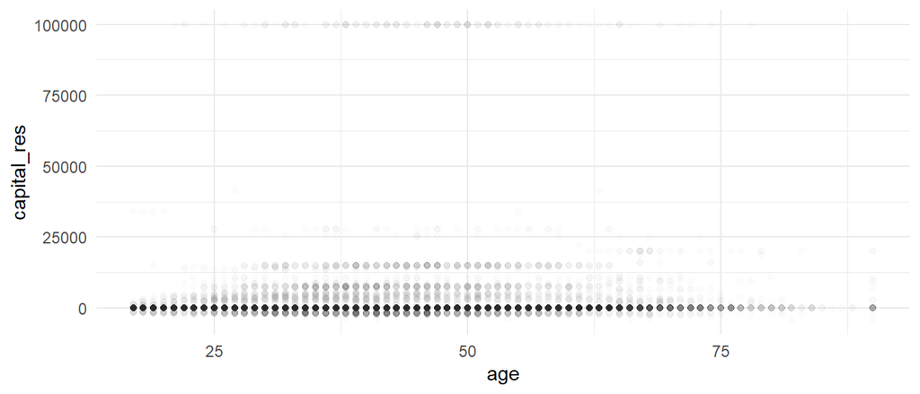

```r
ggplot(adult_newvars_capital, aes(age, capital_res)) +
  geom_point(alpha = .01) +
  theme_minimal()
```

En combinant les deux variables en une seule qualitative, on remarque que les pertes ayant un investissement, quelque soit le résultat de celui-ci, sont plus âgées que les autres.

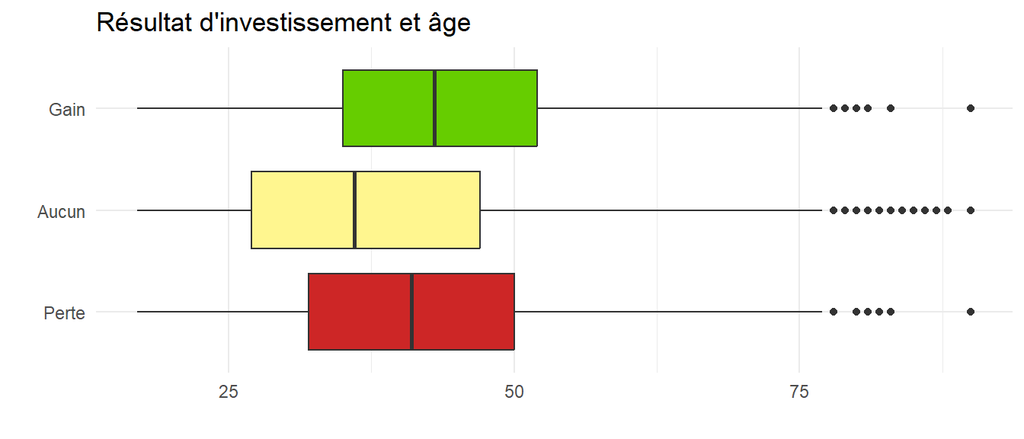

```r
ggplot(adult_newvars_capital, aes(age, capital_res_cat, fill = capital_res_cat)) +
  geom_boxplot(show.legend = FALSE) +
  scale_y_discrete(limits = c("Perte", "Aucun", "Gain")) +
  scale_fill_manual(
    limits = c("Perte", "Aucun", "Gain"),
    values = c("firebrick3", "khaki1", "chartreuse3")
    ) +
  theme_minimal() +
  labs(x = "", y = "") +
  ggtitle("Résultat d'investissement et âge")
```